# Chapter 2 In-Class R Demo: Mean, Variance, and ACF

## Demo Goal

You will see why time-series data need covariance and autocorrelation, not only mean and variance.

Reference anchor: stationarity, autocovariance, and sample ACF ideas from the reference texts.

```r
set.seed(311)
par(mfrow = c(1, 1))
```

## 1. Two Series with Similar Mean and Variance

```r
n <- 200
white_noise <- rnorm(n)

ar_series <- numeric(n)
phi <- 0.8
eps <- rnorm(n, sd = sqrt(1 - phi^2))  # Var(X_t) = 1, like the noise
for (t in 2:n) {
  ar_series[t] <- phi * ar_series[t - 1] + eps[t]
}

mean(white_noise)
```

```
## [1] -0.04495111
```

```r
var(white_noise)
```

```
## [1] 0.9253942
```

```r
mean(ar_series)
```

```
## [1] -0.2049097
```

```r
var(ar_series)
```

```
## [1] 1.020074
```

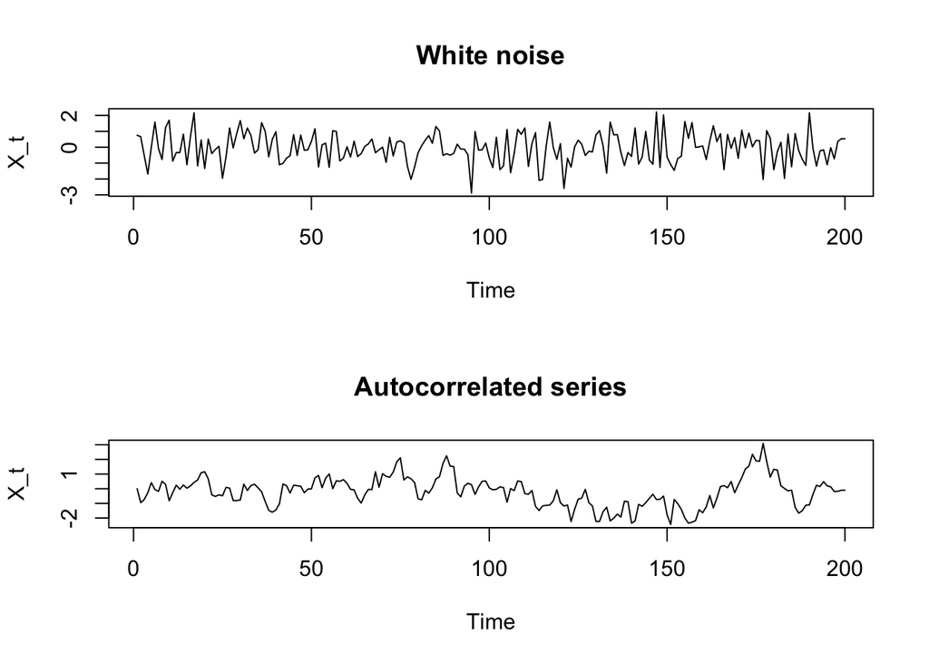

```r
par(mfrow = c(2, 1))
plot.ts(white_noise, main = "White noise", ylab = "X_t")
plot.ts(ar_series, main = "Autocorrelated series", ylab = "X_t")
```

```r
par(mfrow = c(1, 1))
```

Questions:

- If the mean and variance are not enough, what extra feature do we need?

## 2. ACF as a Picture of Memory

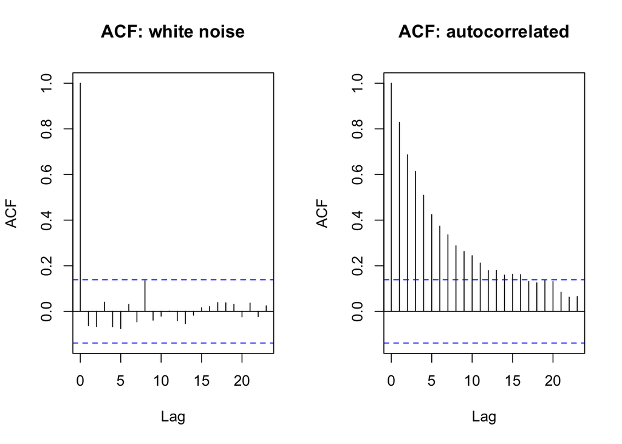

```r
par(mfrow = c(1, 2))
acf(white_noise, main = "ACF: white noise")
acf(ar_series, main = "ACF: autocorrelated")
```

```r
par(mfrow = c(1, 1))
```

Questions:

- Which series remembers its past?
- How does the ACF show this?

## 3. Manual Autocovariance

```r
sample_autocov <- function(x, h) {
  xbar <- mean(x)
  n <- length(x)
  sum((x[(h + 1):n] - xbar) * (x[1:(n - h)] - xbar)) / n
}

gamma0 <- sample_autocov(ar_series, 0)
gamma1 <- sample_autocov(ar_series, 1)
rho1 <- gamma1 / gamma0

c(gamma0 = gamma0, gamma1 = gamma1, rho1 = rho1)
```

```
##    gamma0    gamma1      rho1
## 1.0149739 0.8408057 0.8284014
```

```r
acf(ar_series, plot = FALSE)$acf[1:3]
```

```
## [1] 1.0000000 0.8284014 0.6862558
```

Try it yourself:

- Change `phi <- 0.8` to `phi <- -0.8`.
- Rerun the plots and ACF.
- Why does the series now alternate?

## 4. ACF by Hand with Five Observations

Start with a small series, so you can check every number by hand.

```r
x_small <- c(4, 5, 6, 5, 4)
xbar <- mean(x_small)
deviation <- x_small - xbar

data.frame(
  t = seq_along(x_small),
  x = x_small,
  deviation = deviation
)
```

```
##   t x deviation
## 1 1 4      -0.8
## 2 2 5       0.2
## 3 3 6       1.2
## 4 4 5       0.2
## 5 5 4      -0.8
```

The lag 0 autocovariance is the average squared deviation.

```r
gamma0_parts <- deviation * deviation
gamma0 <- sum(gamma0_parts) / length(x_small)

data.frame(part = gamma0_parts)
```

```
##   part
## 1 0.64
## 2 0.04
## 3 1.44
## 4 0.04
## 5 0.64
```

```r
gamma0
```

```
## [1] 0.56
```

The lag 1 autocovariance compares each deviation with the previous deviation.

```r
lag1_parts <- deviation[2:5] * deviation[1:4]
gamma1 <- sum(lag1_parts) / length(x_small)
rho1 <- gamma1 / gamma0

data.frame(
  current_deviation = deviation[2:5],
  previous_deviation = deviation[1:4],
  product = lag1_parts
)
```

```
##   current_deviation previous_deviation product
## 1               0.2               -0.8   -0.16
## 2               1.2                0.2    0.24
## 3               0.2                1.2    0.24
## 4              -0.8                0.2   -0.16
```

```r
c(gamma1 = gamma1, rho1 = rho1)
```

```
##     gamma1       rho1
## 0.03200000 0.05714286
```

The lag 2 autocovariance compares observations two periods apart.

```r
lag2_parts <- deviation[3:5] * deviation[1:3]
gamma2 <- sum(lag2_parts) / length(x_small)
rho2 <- gamma2 / gamma0

data.frame(
  current_deviation = deviation[3:5],
  lag2_deviation = deviation[1:3],
  product = lag2_parts
)
```

```
##   current_deviation lag2_deviation product
## 1               1.2           -0.8   -0.96
## 2               0.2            0.2    0.04
## 3              -0.8            1.2   -0.96
```

```r
c(gamma2 = gamma2, rho2 = rho2)
```

```
##     gamma2       rho2
## -0.3760000 -0.6714286
```

Compare the hand calculation with R’s built-in ACF.

```r
acf(x_small, plot = FALSE)$acf[1:3]
```

```
## [1]  1.00000000  0.05714286 -0.67142857
```

Questions:

- What does a positive product mean?
- What does a negative product mean?
- Why can lag 2 be negative even when lag 1 is near zero?

## 5. Predict the ACF Before Plotting

```r
upward <- c(2, 3, 4, 5, 6)
zigzag <- c(2, 6, 2, 6, 2)
flat <- c(3, 3, 3, 3, 3)

acf_by_hand <- function(x, max_lag = 4) {
  xbar <- mean(x)
  dev <- x - xbar
  gamma0 <- sum(dev * dev) / length(x)
  out <- data.frame(lag = 0:max_lag, gamma = NA_real_, rho = NA_real_)
  for (h in 0:max_lag) {
    products <- dev[(h + 1):length(x)] * dev[1:(length(x) - h)]
    out$gamma[h + 1] <- sum(products) / length(x)
    out$rho[h + 1] <- out$gamma[h + 1] / gamma0
  }
  out
}

acf_by_hand(upward)
```

```
##   lag gamma  rho
## 1   0   2.0  1.0
## 2   1   0.8  0.4
## 3   2  -0.2 -0.1
## 4   3  -0.8 -0.4
## 5   4  -0.8 -0.4
```

```r
acf_by_hand(zigzag)
```

```
##   lag  gamma        rho
## 1   0  3.840  1.0000000
## 2   1 -3.072 -0.8000000
## 3   2  2.176  0.5666667
## 4   3 -1.536 -0.4000000
## 5   4  0.512  0.1333333
```

For `flat`, the ACF is not meaningful because there is no variation.

```r
var(flat)
```

```
## [1] 0
```

## 6. Covariance and Correlation: Air Quality in New York

The notes use the 26 complete days of May 1973 from the built-in `airquality` data. Here we use all complete days, May to September 1973 (ozone in ppb, solar radiation, wind speed in mph, temperature in degrees F).

```r
air <- na.omit(airquality[, c("Ozone", "Solar.R", "Wind", "Temp")])
head(air)
```

```
##   Ozone Solar.R Wind Temp
## 1    41     190  7.4   67
## 2    36     118  8.0   72
## 3    12     149 12.6   74
## 4    18     313 11.5   62
## 7    23     299  8.6   65
## 8    19      99 13.8   59
```

```r
summary(air)
```

```
##      Ozone          Solar.R           Wind            Temp
##  Min.   :  1.0   Min.   :  7.0   Min.   : 2.30   Min.   :57.00
##  1st Qu.: 18.0   1st Qu.:113.5   1st Qu.: 7.40   1st Qu.:71.00
##  Median : 31.0   Median :207.0   Median : 9.70   Median :79.00
##  Mean   : 42.1   Mean   :184.8   Mean   : 9.94   Mean   :77.79
##  3rd Qu.: 62.0   3rd Qu.:255.5   3rd Qu.:11.50   3rd Qu.:84.50
##  Max.   :168.0   Max.   :334.0   Max.   :20.70   Max.   :97.00
```

```r
dim(air)
```

```
## [1] 111   4
```

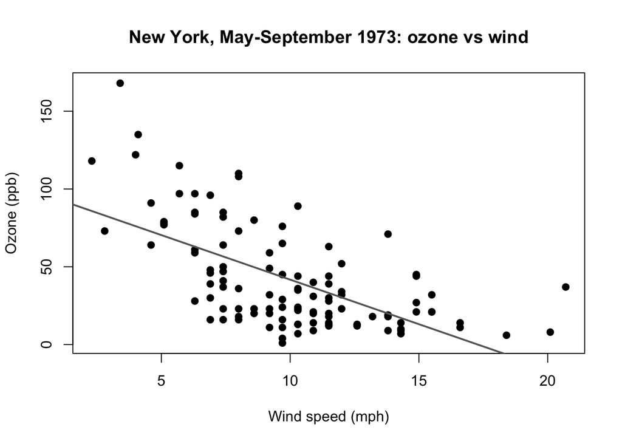

```r
plot(air$Wind, air$Ozone, pch = 19,
     xlab = "Wind speed (mph)", ylab = "Ozone (ppb)",
     main = "New York, May-September 1973: ozone vs wind")
fit_a <- lm(Ozone ~ Wind, data = air)
abline(fit_a, col = "grey40", lwd = 2)
```

```r
coef(fit_a)
```

```
## (Intercept)        Wind
##   99.041277   -5.728797
```

```r
summary(fit_a)$r.squared
```

```
## [1] 0.3751521
```

`cov()` and `cor()` use the divisor n - 1. Check them by hand.

```r
n <- nrow(air)
dev_oz <- air$Ozone - mean(air$Ozone)
dev_wd <- air$Wind - mean(air$Wind)

c(cov_R = cov(air$Ozone, air$Wind),
  cov_hand = sum(dev_oz * dev_wd) / (n - 1))
```

```
##     cov_R  cov_hand
## -72.51124 -72.51124
```

```r
c(cor_R = cor(air$Ozone, air$Wind),
  cor_hand = sum(dev_oz * dev_wd) / sqrt(sum(dev_oz^2) * sum(dev_wd^2)))
```

```
##      cor_R   cor_hand
## -0.6124966 -0.6124966
```

```r
round(cor(air), 2)
```

```
##         Ozone Solar.R  Wind  Temp
## Ozone    1.00    0.35 -0.61  0.70
## Solar.R  0.35    1.00 -0.13  0.29
## Wind    -0.61   -0.13  1.00 -0.50
## Temp     0.70    0.29 -0.50  1.00
```

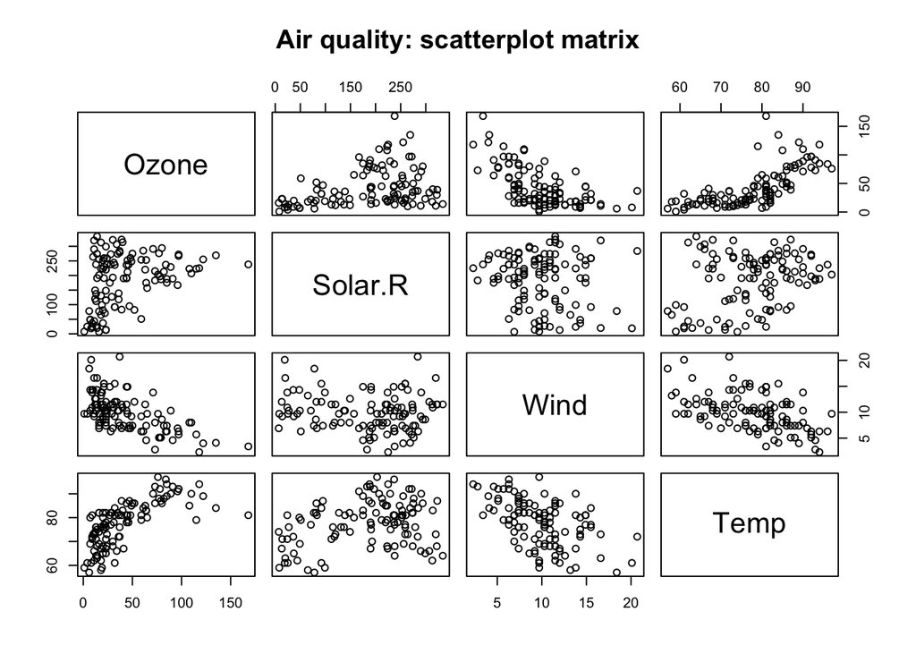

```r
pairs(air, main = "Air quality: scatterplot matrix")
```

Questions:

- Is the linear association between ozone and wind strong or weak? Which points drive it? Compare with the May-only value in the notes.
- Why is the squared correlation equal to the R-squared of the fitted line?
- Do the divisors n and n - 1 change the correlation? Why not?
- The observations are consecutive days. Why might that matter when we judge whether a correlation is “significant” (Chapter 2, Section 2.4)?

## 7. Lag Scatterplots and the ACF: Wave Heights

The simulated wave heights of the wave-height example in the notes (396 readings in mm). A lag-k scatterplot plots each value against the value k steps later.

```r
set.seed(311)
wave <- round(arima.sim(model = list(ar = c(0.8, -0.6)), n = 396, sd = 200))
summary(as.numeric(wave))
```

```
##    Min. 1st Qu.  Median    Mean 3rd Qu.    Max.
## -733.00 -201.75   -3.50  -14.43  172.50  570.00
```

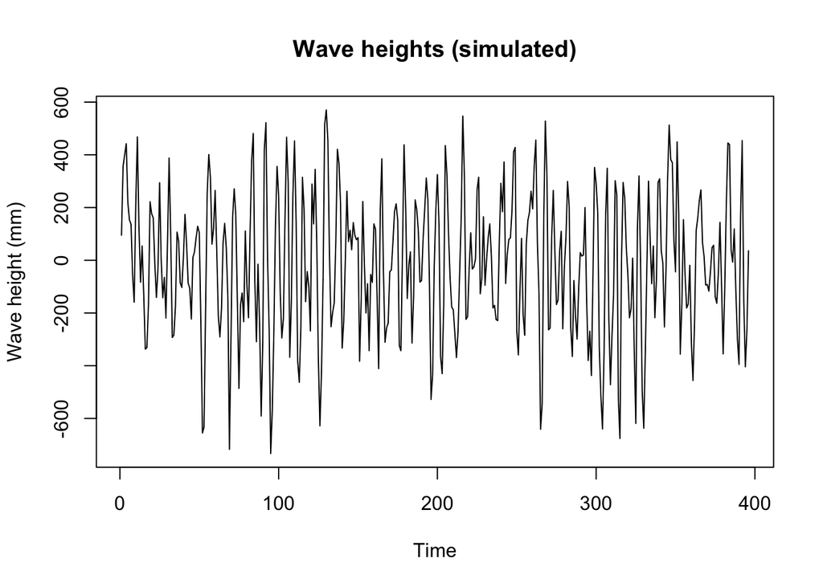

```r
plot(wave, main = "Wave heights (simulated)",
     xlab = "Time", ylab = "Wave height (mm)")
```

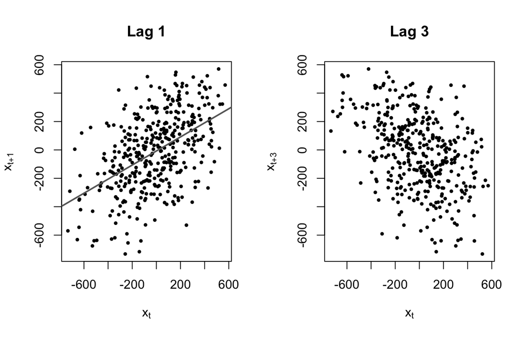

```r
n <- length(wave)
par(mfrow = c(1, 2))
plot(wave[1:(n - 1)], wave[2:n], pch = 19, cex = 0.5,
     main = "Lag 1", xlab = expression(x[t]), ylab = expression(x[t + 1]))
fit_lag1 <- lm(wave[2:n] ~ wave[1:(n - 1)])
abline(fit_lag1, col = "grey40", lwd = 2)
plot(wave[1:(n - 3)], wave[4:n], pch = 19, cex = 0.5,
     main = "Lag 3", xlab = expression(x[t]), ylab = expression(x[t + 3]))
```

```r
par(mfrow = c(1, 1))

coef(fit_lag1)[2]                    # slope of the lag-1 line
```

```
## wave[1:(n - 1)]
##       0.4957141
```

```r
acf(wave, plot = FALSE)$acf[2]       # sample ACF at lag 1
```

```
## [1] 0.495669
```

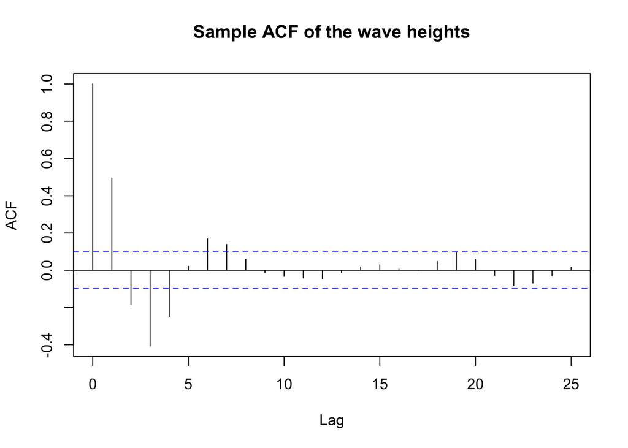

```r
acf_wave <- acf(wave, main = "Sample ACF of the wave heights")
```

```r
round(acf_wave$acf[2:11], 3)         # lags 1 to 10
```

```
##  [1]  0.496 -0.184 -0.407 -0.248  0.021  0.169  0.139  0.058 -0.011 -0.032
```

```r
rho1 <- acf_wave$acf[2]
bound <- 1.96 / sqrt(length(wave))
cat(sprintf("Lag-1 ACF: %.3f; 95%% bounds: +/-%.4f; the value lies %s.\n",
            rho1, bound, if (abs(rho1) > bound) "outside" else "inside"))
```

```
## Lag-1 ACF: 0.496; 95% bounds: +/-0.0985; the value lies outside.
```

Questions:

- Why is the slope of the lag-1 line close to the lag-1 sample ACF?
- What does the lag-3 scatterplot show, and how does it match the ACF at lag 3?
- How many lags fall outside the bounds? Would you expect any for iid white noise?

Try it yourself:

- Run `lag.plot(wave, lags = 4)` to see lags 1 to 4 at once.
- Replace `wave` by `LakeHuron` or `lh` and compare the lag plots and ACF.

## 8. The ACF of Nonstationary Series

A random walk $X_t = X_{t-1} + \epsilon_t$ and the `AirPassengers` series of the notes. The sample ACF can be computed for any data, but here it does not estimate the ACF of a stationary process.

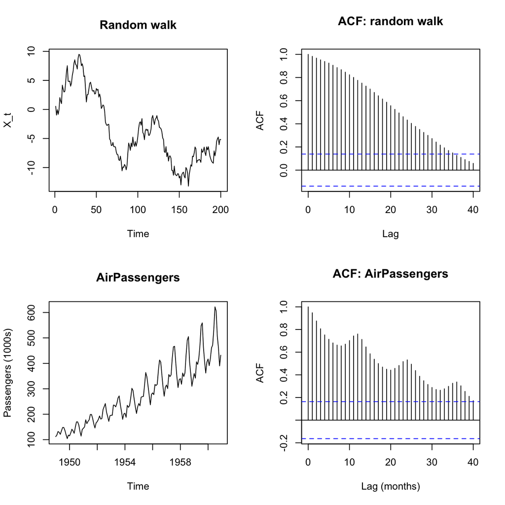

```r
rw <- cumsum(rnorm(200))               # random walk with X_0 = 0
par(mfrow = c(2, 2))
plot.ts(rw, main = "Random walk", ylab = "X_t")
acf(rw, lag.max = 40, main = "ACF: random walk")
plot(AirPassengers, main = "AirPassengers", ylab = "Passengers (1000s)")
acf(as.numeric(AirPassengers), lag.max = 40, main = "ACF: AirPassengers",
    xlab = "Lag (months)")
```

```r
par(mfrow = c(1, 1))
```

Questions:

- Why does the random-walk sample ACF start near 1 and decay almost linearly, although $\text{E}(X_t) = 0$ for every $t$?
- At which lags does the `AirPassengers` ACF have local peaks, and why?

Try it yourself:

- Run `acf(diff(rw))`. What do the differences look like?